# Birds Data

This data set is on bird assemblages in a montane forest in the Velka Fatra Mountains (Slovak Republic).

```r
library("vegan")
library("readr")
library("tidyr")
library("dplyr")
library("tibble")
```

We can load the bird data and process it into two data sets

1. the species abundances, and
2. the associated environmental variables.

```r
birds_url <- "https://bit.ly/maed-birds"

birds <- read_csv(birds_url, na = "", skip = 1)
```

[output not shown]

```r
birds_spp <- birds |>
    mutate(across(AegiCaud:OriOri, ~ replace_na(.x, 0))) |>
    column_to_rownames("...1")
birds_spp <- birds_spp[, 1:36]

birds_env <- birds |>
    select(c("...1", Altit:Expos)) |>
    mutate(Rocks = factor(Rocks), Expos = factor(Expos)) |>
    column_to_rownames("...1")
```

The aim of the analysis is to find a good ordination of the species data (choose your ordination method, transformation, dissimilarity, etc according to what features of the species data you want to focus on). Then, having found a good ordination, use the environmental data to try to explain the ordination axes or mapping you have created.

The variables are:

- Altitude
- Forest cover
- Forest density
- Amount of broad leaf trees
- E2 layer (scrub layer cover)
- E2 layer conifers
- E1 layer (herb layer cover)
- E1 height
- Slope
- Presence of rocks
- Exposure

# How the Canoco developers would analyse these data

They treat the data as “compositional” (despite them being the average number of breeding pairs averaged over 4 visits to each sampling location).

```r
birds_pca <- pca(birds_spp)

birds_pca
```

```
##
## Call: pca(X = birds_spp)
##
##               Inertia Rank
## Total           4.555
## Unconstrained   4.555   36
##
## Inertia is variance
##
## Eigenvalues for unconstrained axes:
##    PC1    PC2    PC3    PC4    PC5    PC6    PC7    PC8
## 0.9069 0.7557 0.4542 0.4004 0.3159 0.2353 0.2228 0.1959
## (Showing 8 of 36 unconstrained eigenvalues)
```

```r
summary(eigenvals(birds_pca))
```

```
## Importance of components:
##                          PC1    PC2     PC3     PC4     PC5     PC6     PC7
## Eigenvalue            0.9069 0.7557 0.45421 0.40040 0.31589 0.23532 0.22275
## Proportion Explained  0.1991 0.1659 0.09973 0.08791 0.06936 0.05167 0.04891
## Cumulative Proportion 0.1991 0.3651 0.46478 0.55269 0.62205 0.67372 0.72262
##                           PC8     PC9    PC10    PC11   PC12    PC13    PC14
## Eigenvalue            0.19587 0.16030 0.13292 0.11956 0.1039 0.09980 0.08050
## Proportion Explained  0.04301 0.03519 0.02918 0.02625 0.0228 0.02191 0.01767
## Cumulative Proportion 0.76563 0.80082 0.83001 0.85626 0.8791 0.90097 0.91865
##                          PC15    PC16    PC17     PC18     PC19     PC20
## Eigenvalue            0.06215 0.05467 0.04062 0.035465 0.032653 0.028140
## Proportion Explained  0.01364 0.01200 0.00892 0.007787 0.007169 0.006178
## Cumulative Proportion 0.93229 0.94430 0.95322 0.961002 0.968172 0.974350
##                           PC21     PC22     PC23     PC24     PC25     PC26
## Eigenvalue            0.021960 0.020116 0.014740 0.011911 0.009596 0.008122
## Proportion Explained  0.004822 0.004417 0.003236 0.002615 0.002107 0.001783
## Cumulative Proportion 0.979172 0.983589 0.986825 0.989440 0.991547 0.993330
##                           PC27     PC28      PC29      PC30      PC31      PC32
## Eigenvalue            0.007375 0.004942 0.0045034 0.0034125 0.0031614 0.0025260
## Proportion Explained  0.001619 0.001085 0.0009888 0.0007492 0.0006941 0.0005546
## Cumulative Proportion 0.994950 0.996035 0.9970237 0.9977730 0.9984671 0.9990217
##                            PC33      PC34      PC35      PC36
## Eigenvalue            0.0019434 0.0012993 0.0007002 0.0005127
## Proportion Explained  0.0004267 0.0002853 0.0001537 0.0001126
## Cumulative Proportion 0.9994484 0.9997337 0.9998874 1.0000000
```

```r
plot(birds_pca)

ev_pca <- envfit(birds_pca ~ Altit, data = birds_env)
ev_pca
```

```
##
## ***VECTORS
##
##            PC1      PC2     r2 Pr(>r)
## Altit -0.96310  0.26913 0.4583  0.001 ***
## ---
## Signif. codes:  0 '***' 0.001 '**' 0.01 '*' 0.05 '.' 0.1 ' ' 1
## Permutation: free
## Number of permutations: 999
```

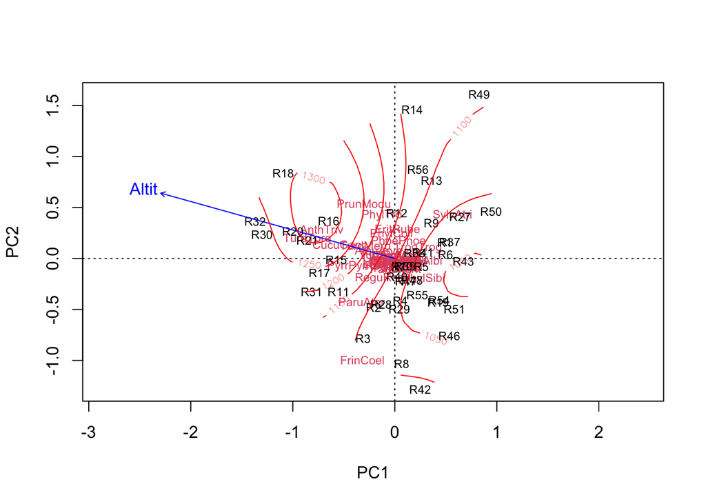

```
##
## Family: gaussian
## Link function: identity
##
## Formula:
## y ~ s(x1, x2, k = 10, bs = "tp", fx = FALSE)
##
## Estimated degrees of freedom:
## 5.21  total = 6.21
##
## REML score: 257.1538
```

```r
plot(ev_pca, add = TRUE)

ordisurf(birds_pca ~ Altit, data = birds_env, add = TRUE)
```

# How I might have approached this

```r
birds_ca <- ca(birds_spp)

birds_ca
```

```
##
## Call: ca(X = birds_spp)
##
##               Inertia Rank
## Total           1.476
## Unconstrained   1.476   35
##
## Inertia is scaled Chi-square
##
## Eigenvalues for unconstrained axes:
##     CA1     CA2     CA3     CA4     CA5     CA6     CA7     CA8
## 0.21320 0.17737 0.11419 0.11092 0.09765 0.09175 0.07321 0.06225
## (Showing 8 of 35 unconstrained eigenvalues)
```

```r
summary(eigenvals(birds_ca))
```

```
## Importance of components:
##                          CA1    CA2     CA3     CA4     CA5     CA6     CA7
## Eigenvalue            0.2132 0.1774 0.11419 0.11092 0.09765 0.09175 0.07321
## Proportion Explained  0.1444 0.1201 0.07734 0.07513 0.06614 0.06215 0.04959
## Cumulative Proportion 0.1444 0.2645 0.34188 0.41701 0.48315 0.54529 0.59488
##                           CA8     CA9    CA10    CA11    CA12    CA13    CA14
## Eigenvalue            0.06225 0.05758 0.05531 0.04542 0.03964 0.03699 0.03535
## Proportion Explained  0.04216 0.03900 0.03746 0.03076 0.02685 0.02505 0.02394
## Cumulative Proportion 0.63704 0.67604 0.71350 0.74426 0.77111 0.79616 0.82011
##                          CA15    CA16    CA17    CA18    CA19    CA20    CA21
## Eigenvalue            0.03089 0.02835 0.02686 0.02382 0.02193 0.01941 0.01854
## Proportion Explained  0.02092 0.01920 0.01819 0.01613 0.01485 0.01315 0.01256
## Cumulative Proportion 0.84103 0.86023 0.87842 0.89456 0.90941 0.92255 0.93511
##                          CA22     CA23     CA24     CA25     CA26     CA27
## Eigenvalue            0.01745 0.013675 0.012507 0.011456 0.009717 0.007770
## Proportion Explained  0.01182 0.009262 0.008471 0.007759 0.006581 0.005263
## Cumulative Proportion 0.94693 0.956191 0.964661 0.972421 0.979002 0.984265
##                           CA28     CA29     CA30     CA31     CA32     CA33
## Eigenvalue            0.006807 0.005525 0.003228 0.002477 0.001760 0.001593
## Proportion Explained  0.004610 0.003742 0.002187 0.001677 0.001192 0.001079
## Cumulative Proportion 0.988875 0.992617 0.994804 0.996481 0.997673 0.998752
##                            CA34      CA35
## Eigenvalue            0.0012725 0.0005700
## Proportion Explained  0.0008619 0.0003861
## Cumulative Proportion 0.9996139 1.0000000
```

```r
plot(birds_ca)

ev_ca <- envfit(birds_ca ~ Altit, data = birds_env)
ev_ca
```

```
##
## ***VECTORS
##
##            CA1      CA2     r2 Pr(>r)
## Altit  0.47349 -0.88080 0.5684  0.001 ***
## ---
## Signif. codes:  0 '***' 0.001 '**' 0.01 '*' 0.05 '.' 0.1 ' ' 1
## Permutation: free
## Number of permutations: 999
```

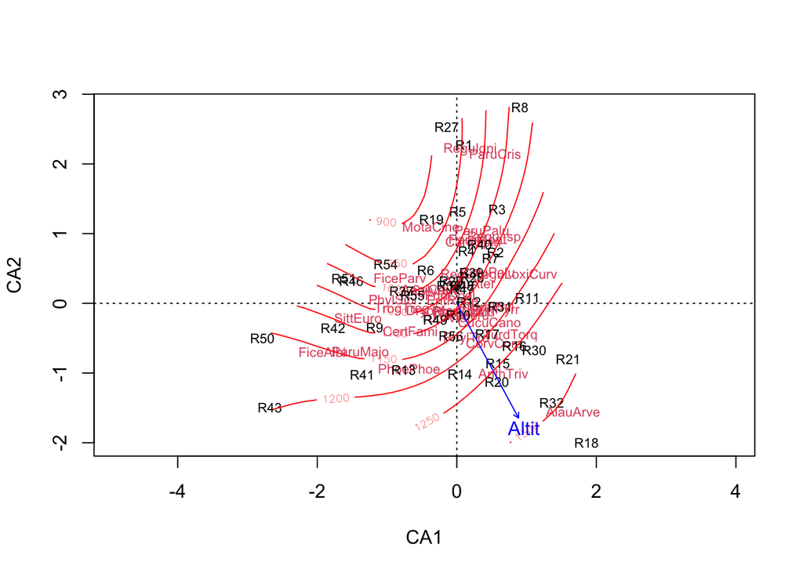

```
##
## Family: gaussian
## Link function: identity
##
## Formula:
## y ~ s(x1, x2, k = 10, bs = "tp", fx = FALSE)
##
## Estimated degrees of freedom:
## 6.76  total = 7.76
##
## REML score: 248.5029
```

```r
plot(ev_ca, add = TRUE)

ordisurf(birds_ca ~ Altit, data = birds_env, add = TRUE)
```

or

```r
birds_h <- pca(decostand(birds_spp, method = "hellinger"))

birds_h
```

```
##
## Call: pca(X = decostand(birds_spp, method = "hellinger"))
##
##               Inertia Rank
## Total           0.313
## Unconstrained   0.313   36
##
## Inertia is variance
##
## Eigenvalues for unconstrained axes:
##     PC1     PC2     PC3     PC4     PC5     PC6     PC7     PC8
## 0.05735 0.03967 0.02744 0.02666 0.02018 0.01619 0.01463 0.01420
## (Showing 8 of 36 unconstrained eigenvalues)
```

```r
summary(eigenvals(birds_h))
```

```
## Importance of components:
##                           PC1     PC2     PC3     PC4     PC5     PC6     PC7
## Eigenvalue            0.05735 0.03967 0.02744 0.02666 0.02018 0.01619 0.01463
## Proportion Explained  0.18321 0.12672 0.08766 0.08516 0.06446 0.05171 0.04672
## Cumulative Proportion 0.18321 0.30993 0.39759 0.48275 0.54721 0.59892 0.64564
##                           PC8     PC9    PC10     PC11     PC12     PC13
## Eigenvalue            0.01420 0.01132 0.01078 0.009609 0.008787 0.007767
## Proportion Explained  0.04537 0.03617 0.03444 0.030695 0.028068 0.024810
## Cumulative Proportion 0.69101 0.72718 0.76162 0.792312 0.820380 0.845190
##                           PC14     PC15     PC16     PC17    PC18     PC19
## Eigenvalue            0.006586 0.005725 0.004716 0.004524 0.00399 0.003512
## Proportion Explained  0.021039 0.018288 0.015066 0.014451 0.01274 0.011218
## Cumulative Proportion 0.866229 0.884518 0.899584 0.914035 0.92678 0.937998
##                           PC20     PC21     PC22     PC23     PC24     PC25
## Eigenvalue            0.003175 0.002641 0.002359 0.002027 0.001833 0.001592
## Proportion Explained  0.010141 0.008437 0.007537 0.006475 0.005857 0.005086
## Cumulative Proportion 0.948139 0.956576 0.964112 0.970587 0.976444 0.981530
##                           PC26     PC27      PC28      PC29      PC30      PC31
## Eigenvalue            0.001363 0.001070 0.0008743 0.0007373 0.0006203 0.0004077
## Proportion Explained  0.004353 0.003418 0.0027928 0.0023552 0.0019816 0.0013022
## Cumulative Proportion 0.985883 0.989301 0.9920941 0.9944494 0.9964310 0.9977332
##                            PC32      PC33      PC34      PC35      PC36
## Eigenvalue            0.0002571 0.0002058 0.0001123 7.409e-05 6.044e-05
## Proportion Explained  0.0008212 0.0006573 0.0003586 2.367e-04 1.931e-04
## Cumulative Proportion 0.9985544 0.9992117 0.9995703 9.998e-01 1.000e+00
```

```r
plot(birds_h)

ev_h <- envfit(birds_h ~ Altit, data = birds_env)
ev_h
```

```
##
## ***VECTORS
##
##            PC1      PC2     r2 Pr(>r)
## Altit -0.86211  0.50673 0.4906  0.001 ***
## ---
## Signif. codes:  0 '***' 0.001 '**' 0.01 '*' 0.05 '.' 0.1 ' ' 1
## Permutation: free
## Number of permutations: 999
```

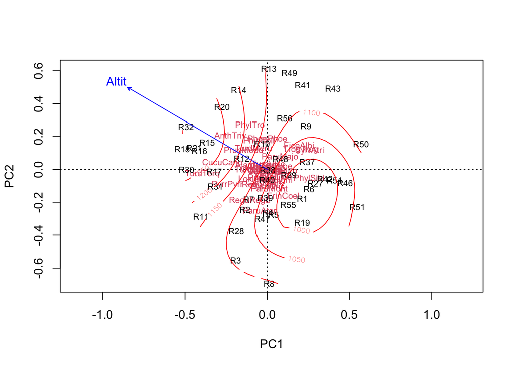

```
##
## Family: gaussian
## Link function: identity
##
## Formula:
## y ~ s(x1, x2, k = 10, bs = "tp", fx = FALSE)
##
## Estimated degrees of freedom:
## 5.54  total = 6.54
##
## REML score: 251.2566
```

```r
plot(ev_h, add = TRUE)

ordisurf(birds_h ~ Altit, data = birds_env, add = TRUE)
```

or

```r
birds_nmds <- metaMDS(decostand(birds_spp, method = "hellinger"),
    dist = "euclidean",
    autotransform = FALSE, expand = FALSE)
```

```
## *** Best solution repeated 1 times
```

```r
birds_nmds
```

```
##
## Call:
## metaMDS(comm = decostand(birds_spp, method = "hellinger"), distance = "euclidean",      autotransform = FALSE, expand = FALSE)
##
## global Multidimensional Scaling using monoMDS
##
## Data:     decostand(birds_spp, method = "hellinger")
## Distance: euclidean
##
## Dimensions: 2
## Stress:     0.2231427
## Stress type 1, weak ties
## Best solution was repeated 1 time in 20 tries
## The best solution was from try 19 (random start)
## Scaling: centring, PC rotation
## Species: non-expanded scores based on 'decostand(birds_spp, method = "hellinger")'
```

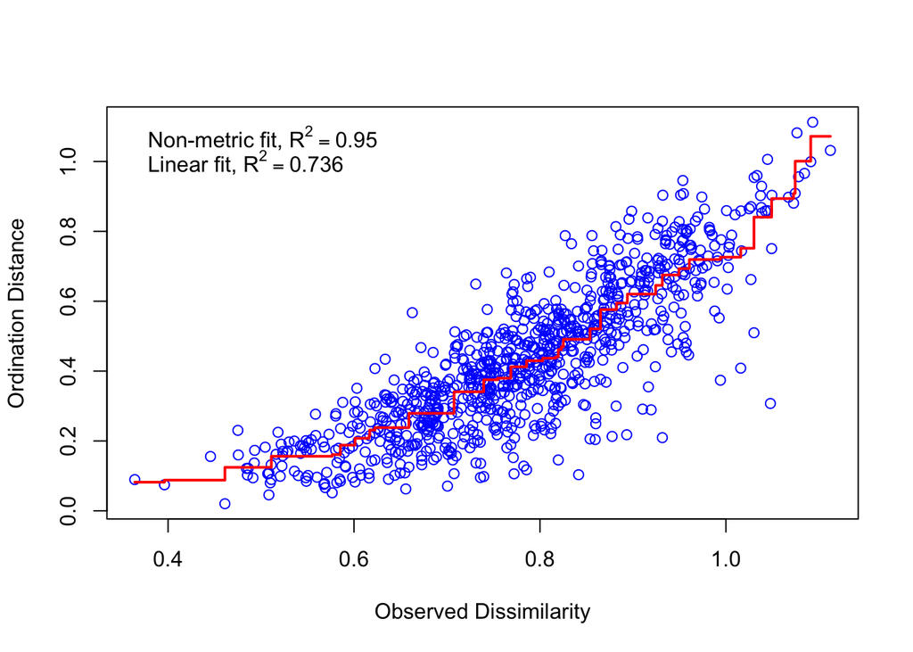

```r
stressplot(birds_nmds)
```

```r
ordipointlabel(birds_nmds)
ev_nmds <- envfit(birds_nmds ~ Altit, data = birds_env)
ev_nmds
```

```
##
## ***VECTORS
##
##         NMDS1   NMDS2    r2 Pr(>r)
## Altit 0.72538 0.68835 0.443  0.001 ***
## ---
## Signif. codes:  0 '***' 0.001 '**' 0.01 '*' 0.05 '.' 0.1 ' ' 1
## Permutation: free
## Number of permutations: 999
```

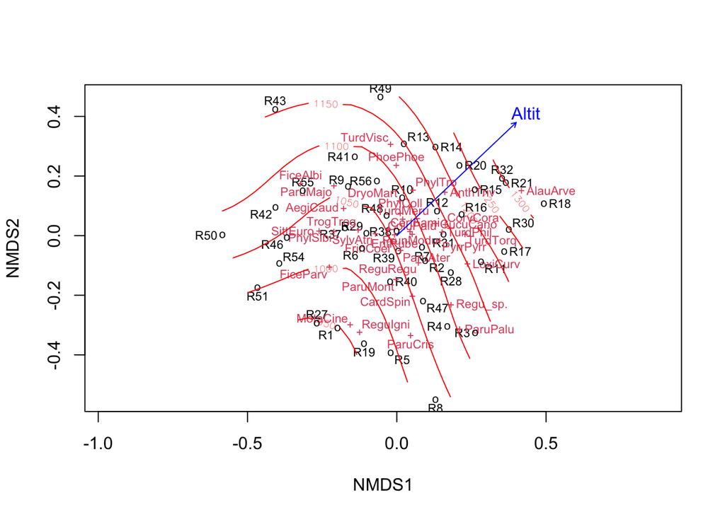

```
##
## Family: gaussian
## Link function: identity
##
## Formula:
## y ~ s(x1, x2, k = 10, bs = "tp", fx = FALSE)
##
## Estimated degrees of freedom:
## 5.45  total = 6.45
##
## REML score: 255.986
```

```r
plot(ev_nmds, add = TRUE)

ordisurf(birds_nmds ~ Altit, data = birds_env, add = TRUE)
```

But does it make any difference?

```r
layout(matrix(1:4, ncol = 2, byrow = TRUE))
plot(birds_pca, main = "PCA")
plot(ev_pca, add = TRUE)
ordisurf(birds_pca ~ Altit, data = birds_env, add = TRUE,
    col = "forestgreen")
```

```
##
## Family: gaussian
## Link function: identity
##
## Formula:
## y ~ s(x1, x2, k = 10, bs = "tp", fx = FALSE)
##
## Estimated degrees of freedom:
## 5.21  total = 6.21
##
## REML score: 257.1538
```

```r
plot(birds_ca, main = "CA")
plot(ev_ca, add = TRUE)
ordisurf(birds_ca ~ Altit, data = birds_env, add = TRUE,
    col = "forestgreen")
```

```
##
## Family: gaussian
## Link function: identity
##
## Formula:
## y ~ s(x1, x2, k = 10, bs = "tp", fx = FALSE)
##
## Estimated degrees of freedom:
## 6.76  total = 7.76
##
## REML score: 248.5029
```

```r
plot(birds_h, main = "PCA (Hellinger)")
plot(ev_h, add = TRUE)
ordisurf(birds_h ~ Altit, data = birds_env, add = TRUE,
    col = "forestgreen")
```

```
##
## Family: gaussian
## Link function: identity
##
## Formula:
## y ~ s(x1, x2, k = 10, bs = "tp", fx = FALSE)
##
## Estimated degrees of freedom:
## 5.54  total = 6.54
##
## REML score: 251.2566
```

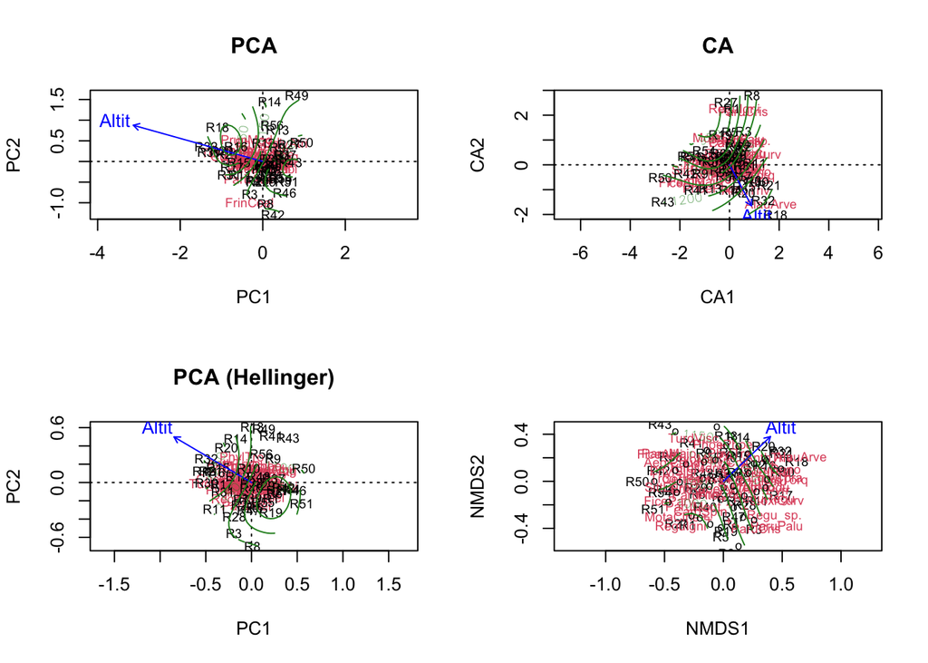

```
##
## Family: gaussian
## Link function: identity
##
## Formula:
## y ~ s(x1, x2, k = 10, bs = "tp", fx = FALSE)
##
## Estimated degrees of freedom:
## 5.45  total = 6.45
##
## REML score: 255.986
```

```r
ordipointlabel(birds_nmds, main = "NMDS")
plot(ev_nmds, add = TRUE)
ordisurf(birds_nmds ~ Altit, data = birds_env, add = TRUE,
    col = "forestgreen")
```

```r
layout(1)
```